# May institute Data visualization module: Hands-on 2

Ting Huang and Dan Guo

May 8, 2017

# Objectives

- Color charts in R
- Change plot colors in ggplot2
  - Change color globally
  - Mapping variable values to colors

Reference: http://www.cookbook-r.com/Graphs/Colors_(ggplot2)/

# 1. Color charts in R

## 1.1 Hexadecimal color code chart

Colors can specified as a hexadecimal RGB triplet, such as “#0066CC”. For example, in the table below, “#FFFFFF” is white and “#990000” is a deep red.

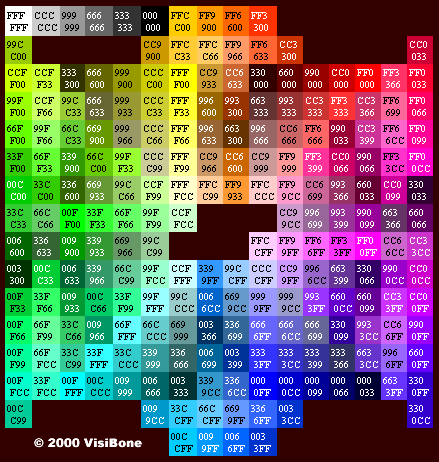

## 1.2 RColorBrewer palette chart

RColorBrewer is a good R package for color palettes. It contains the following color palettes.

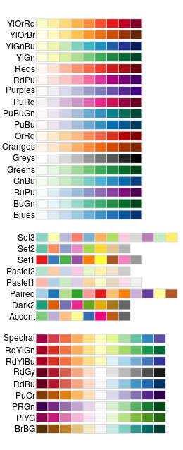

# 2. Change plot colors in ggplot2

In this section we’ll continue using CRC dataset.

```r
library(ggplot2)
CRC <- read.csv("./data/CRC_train.csv")
```

## 2.1 Change color globally

The colors of lines and points can be set directly using colour. The colors of filled objects, like bars, can be set using fill.

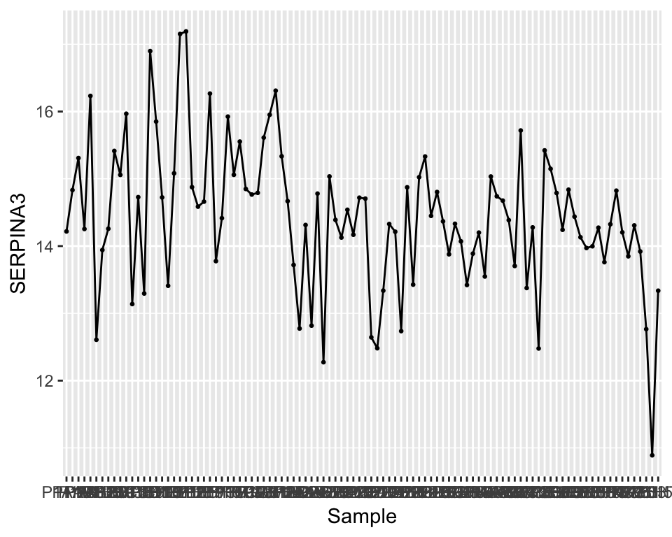

```r
# Default black lines and points
g <- ggplot(CRC[1:100,],aes(Sample, SERPINA3, group = 1))
g + geom_point(size = 0.5) +
  geom_line()
```

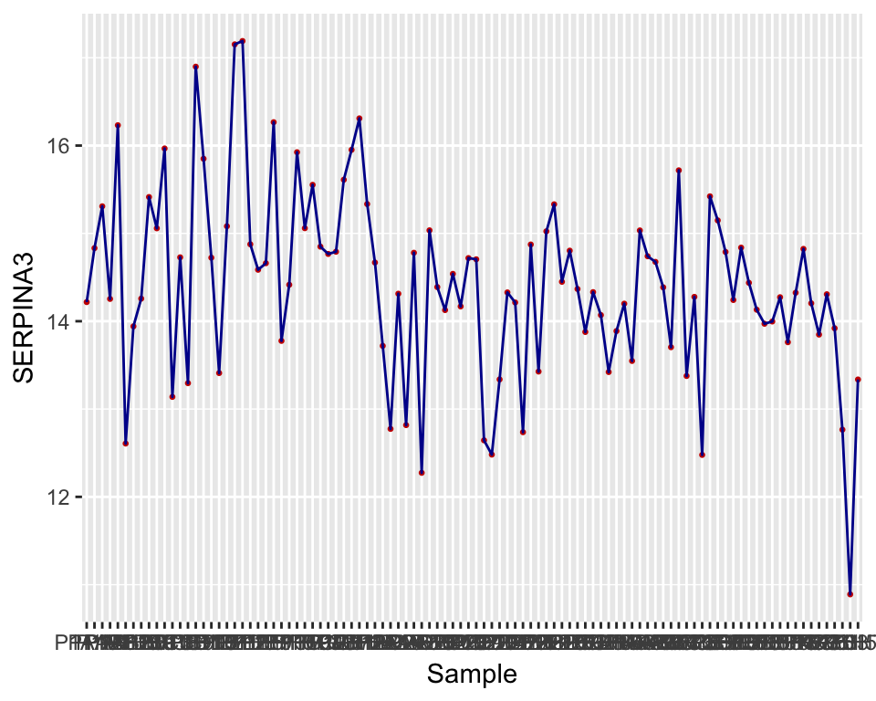

```r
# Dark blue lines, red dots
g + geom_point(size = 0.5, colour="#CC0000") +
  geom_line(colour="#000099")
```